# Statistics in R

## Today's session:

GLM for two more data types/data generating processes:

- Binary response
- Count data

## Recap generalized linear models

Last week we covered GLM as a generalization of linear models. With GLMs you can freely choose how the data is linked to the model (link-function) and which data generating distribution is assumed (data distribution). We covered two models:

- Log link and Gaussian distribution (ozone~temp)
- Logit link and binomial distribution (mortality~concentration)

Today we are going to cover two more common models:

- Logit link and binomial distribution (known as logistic regression; binary response)
- Log link and Poisson distribution (count data)

## Logistic regression

## Logistic regression

We today use a dataset where the response can only take two values. The data indicates whether trees were infested by a bark beetle or not, depending on the temperature anomaly (z-transformed temperatures with values > 0 indicating hotter than average):

```r
dat <- read.csv("Data/infestation.csv")

p <- ggplot(dat, aes(x = temp_anomaly, y = infested)) +
  geom_point()
```

Similar problems include: dead/alive, presence/absence, conversion/conservation, etc.

## Logistic regression

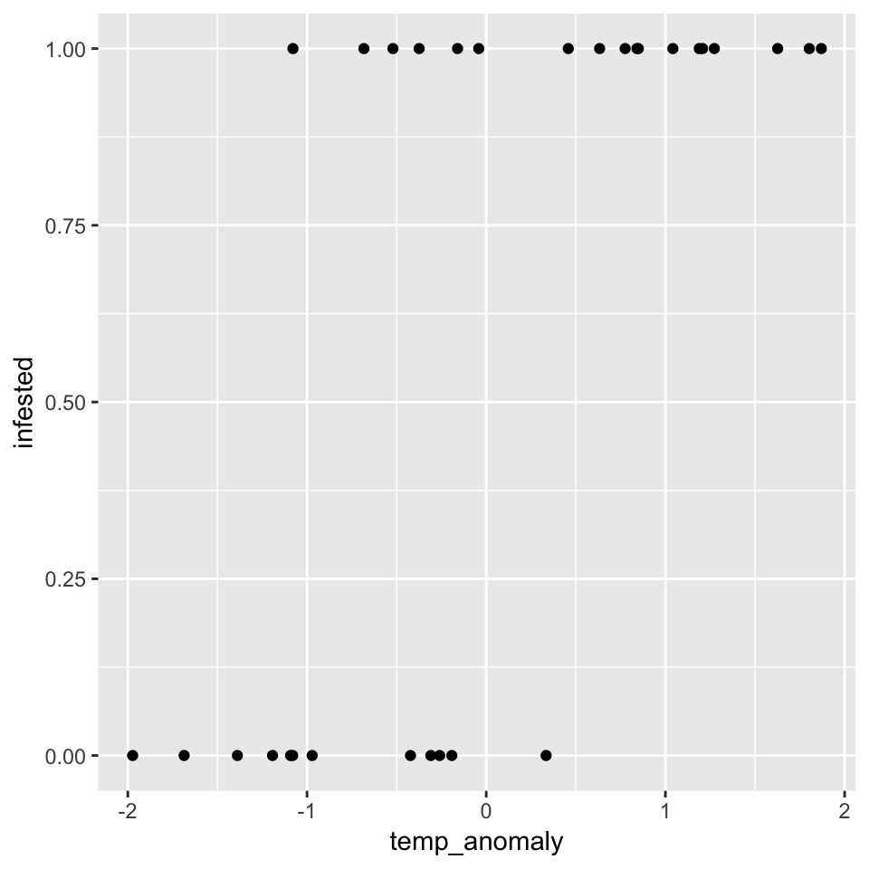

## Logistic regression

We can fit a regression line explaining the relationship between temperature anomaly and infestation:

```r
p <- ggplot(dat, aes(x = temp_anomaly, y = infested)) +
  geom_point() +
  geom_smooth(method = "lm")
```

Does the line fit our data problem?

## Logistic regression

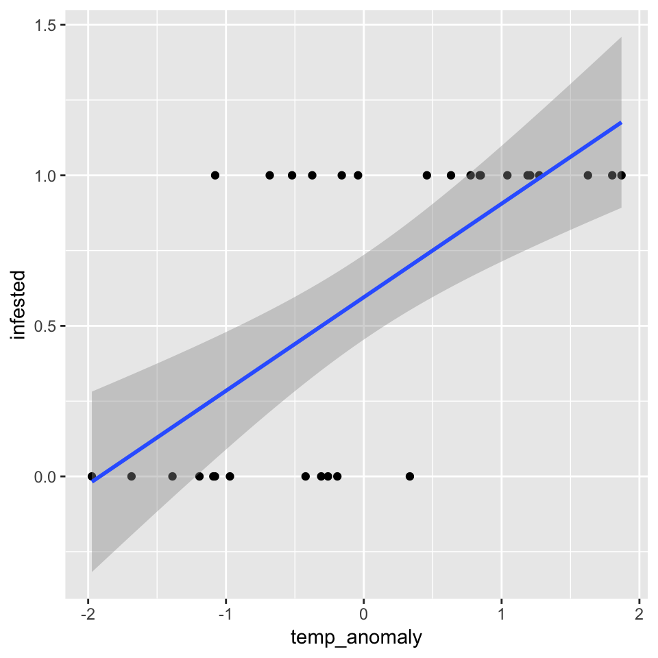

## Logistic regression

It would be nice to model the probability of infestation given a certain temperature anomaly:

\(Pr(infestation = 1) = \beta_0 + \beta_1 * temp\)

Which link function do you think will best fit our problem?

## Logistic regression

The logit link seems well suited as it is bounded between 0 and 1 and alows for a quick transition between both extremes:

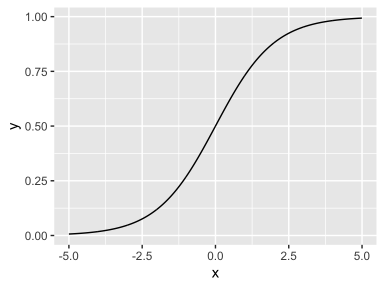

The regression thus can be written as:

\(Pr(infestation = 1) = logit^{−1}(\beta_0 + \beta_1 * temp)) = \frac{1}{1 + e^{-(\beta_0 + \beta_1 * temp)}}\)

## Logistic regression

In our case the data is binomial distributed. Hence, we can relate the probability of infestation modelled through the logit link to our data using a binomial distribution with one trial, which translates into the Bernoulli distribution (a special case of the binomial distribution with only two outcomes):

\(infestation \sim Bernoulli(logit^{−1}(\beta_0 + \beta_1 * temp)))\)

This model is called binomial logistic regression, there are also multinomial (three or more outcomes) and ordinal logistic regression (ordinal outcomes).

## Logistic regression

Fitting a logistic regression model to our data:

```r
fit <- glm(infested ~ temp_anomaly, data = dat, family = binomial(link = "logit"))
```

And plotting the regression line:

```r
prediction <- data.frame(temp_anomaly = seq(-2, 2, length.out = 100))
prediction$fitted <- predict(object = fit, newdata = prediction, type = "response")

p <- ggplot() +
  geom_point(data = dat, aes(x = temp_anomaly, y = infested)) +
  geom_line(data = prediction, aes(x = temp_anomaly, y = fitted))
```

## Logistic regression

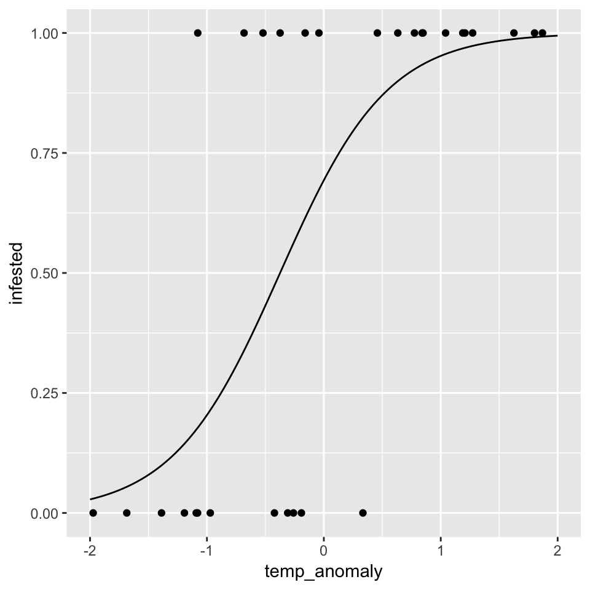

## Logistic regression

To calculate the confidence intervals we have to first calculate them on the link-scale and then backtransform them onto the predictor scale:

```r
pred <- predict(object = fit, newdata = prediction,
                type = "link", se.fit = TRUE)

prediction$fitted_link <- pred$fit
prediction$lower_link <- prediction$fitted_link - 2 * pred$se.fit
prediction$upper_link <- prediction$fitted_link + 2 * pred$se.fit

library(boot) ## Boot package for the inv.logit function

prediction$link <- inv.logit(prediction$fitted_link)
prediction$lower <- inv.logit(prediction$lower_link)
prediction$upper <- inv.logit(prediction$upper_link)
```

And add them to the plot:

```r
p <- ggplot() +
  geom_point(data = dat, aes(x = temp_anomaly, y = infested)) +
  geom_ribbon(data = prediction, aes(x = temp_anomaly, ymin = lower, ymax = upper), alpha = 0.3) +
  geom_line(data = prediction, aes(x = temp_anomaly, y = fitted))
```

## Logistic regression

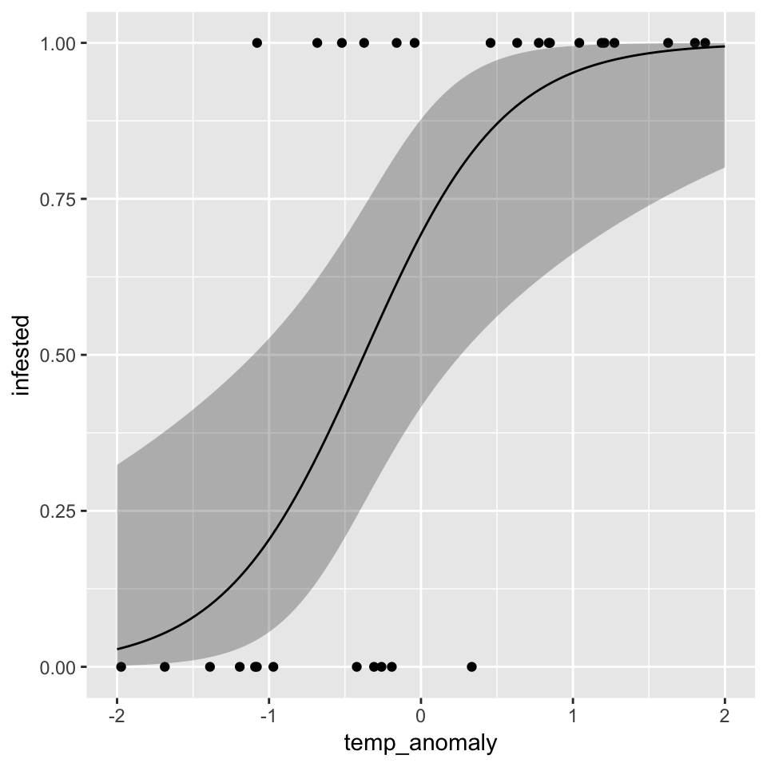

## Logistic regression

Alternatively, we can use the `effect()` function, which does the transformation automatically:

```r
library(effects)

efct <- effect("temp_anomaly",
               mod = fit,
               xlevels = list(temp_anomaly = seq(-2, 2, length.out = 100)))
efct <- as.data.frame(efct)

p <- ggplot() +
  geom_point(data = dat, aes(x = temp_anomaly, y = infested)) +
  geom_ribbon(data = efct, aes(x = temp_anomaly, ymin = lower, ymax = upper), alpha = 0.3) +
  geom_line(data = efct, aes(x = temp_anomaly, y = fit))
```

## Logistic regression

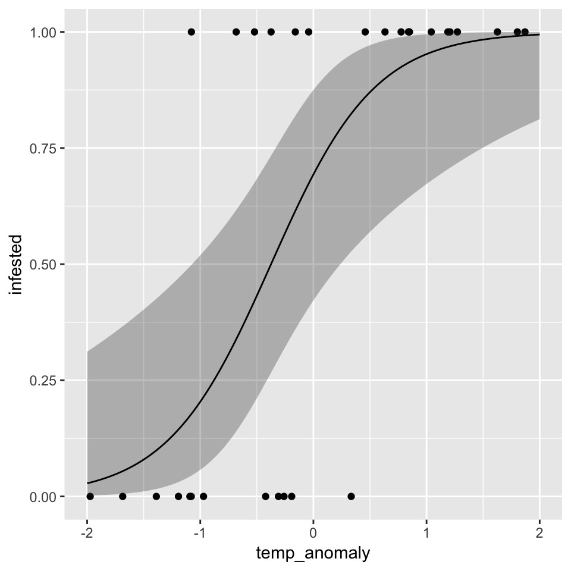

## Logistic regression

Again, it is not straightforward to interpret coefficients in logistic regression, because the change in y given a one unit change in x is non-linear (though linear on the link scale!). However, there are - besides plotting - some ways of making the regression coefficients interpretable.

## Logistic regression

The **divide by 4 rule** by Gelman and Hill (2007) takes the fact that the the logistic curve is steepest at its center (which is zero given scaled predictors).

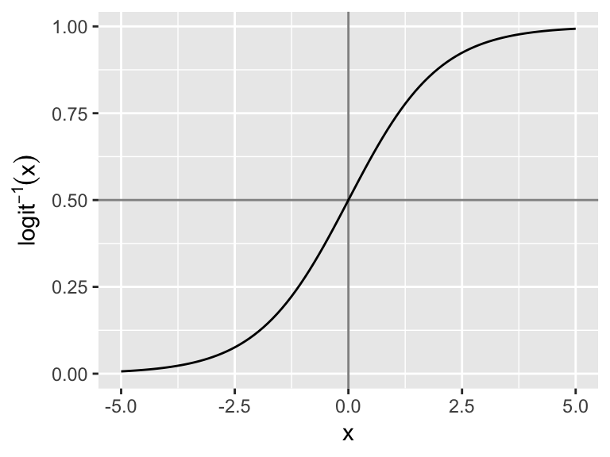

As a rough estimate, we can take logistic regression coefficients and divide them by 4 to get an upper bound of the predictive difference corresponding to a unit difference in x. This upper bound is a good approximation near the midpoint of the logistic curve, where probabilities are close to 0.5.

For further information see: Gelmann and Hill (2007): Data Analysis Using Regression and Multilevel/Hierarchical Models (page 82).

## Logistic regression

In the our example, the regression coefficient was 2.18. Dividing 2.18 by 4 yields 0.54. We can thus say that with an increase in temperature anomaly by one standard deviation, there is an expected increase in infestation probability by no more than 54%.

## Logistic regression

Another way to interpret logistic regression coefficients is in terms of **odds ratios**.

If an success has the probability \(p\) and failure the probability of \((1 − p)\), then \(p/(1 − p)\) is called the odds. Thus, the odds of success are defined as the ratio of the probability of success over the probability of failure.

An odds of 1 is equivalent to a probability of 0.5, that is equally likely outcomes (1:1). An odds of 0.5 is equivalent to a probability of 0.33, indicating there is a 1:2 chance of success/occurence An odds of 2 is eqivalent to a probability of 0.66, indicating a 2:1 change of success/occurence.

## Logistic regression

The ratio of two odds is called an odds ratio: \(\frac{(p1/(1 − p1))}{(p2/(1 − p2))}\) The odds ratio indicates the preference of outcome A over outcome B.

**Example:** We observed a plant species in 6 out of 10 plots in landscape A and in 4 out of 10 plots in landscape B. This gives us probabilities of 0.4 and 0.6. The odds ratio of observing the plant in landscape A over observing it in landscape B is (0.6/0.4) / (0.4/0.6) = 2.25. Hence, there is a 2.25 times higher change of observaing the plant in landscape A compared to landscape B.

## Logistic regression

The logistic regression coefficients give the change in log odds (recall the link function ln(p/1-p)). When exponentiated, logistic regression coefficients can be interpreted as odds ratios:

\(OR = \frac{odds(x + 1)}{odds(x)} = \frac{e^{\beta_0 + \beta_1 * (x + 1)}}{\beta_0 + \beta_1 * x} = e^{\beta_1}\)

For continuous predictors, the coefficients give the change in the log odds of the outcome for a one unit increase in the predictor variable. For categorical predictors, the coefficient estimate describes the change in the log odds for each level compared to the base level.

## Logistic regression

For our example:

```r
exp(coef(fit)[2])
```

```
## temp_anomaly
##     8.826474
```

The odds ratio idicates that with a one SD change in temperature anomaly there is a 8.83 times higher chance of infestation over no infestation.

## Poisson regression

## Poisson regression

The following data sets shows the change in bird counts over an topographic relief gradient:

```r
dat <- read.table("Data/bird_counts.txt", sep = ";", header = TRUE)

p <- ggplot(dat, aes(x = relief, y = Y)) +
  geom_point()
```

## Poisson regression

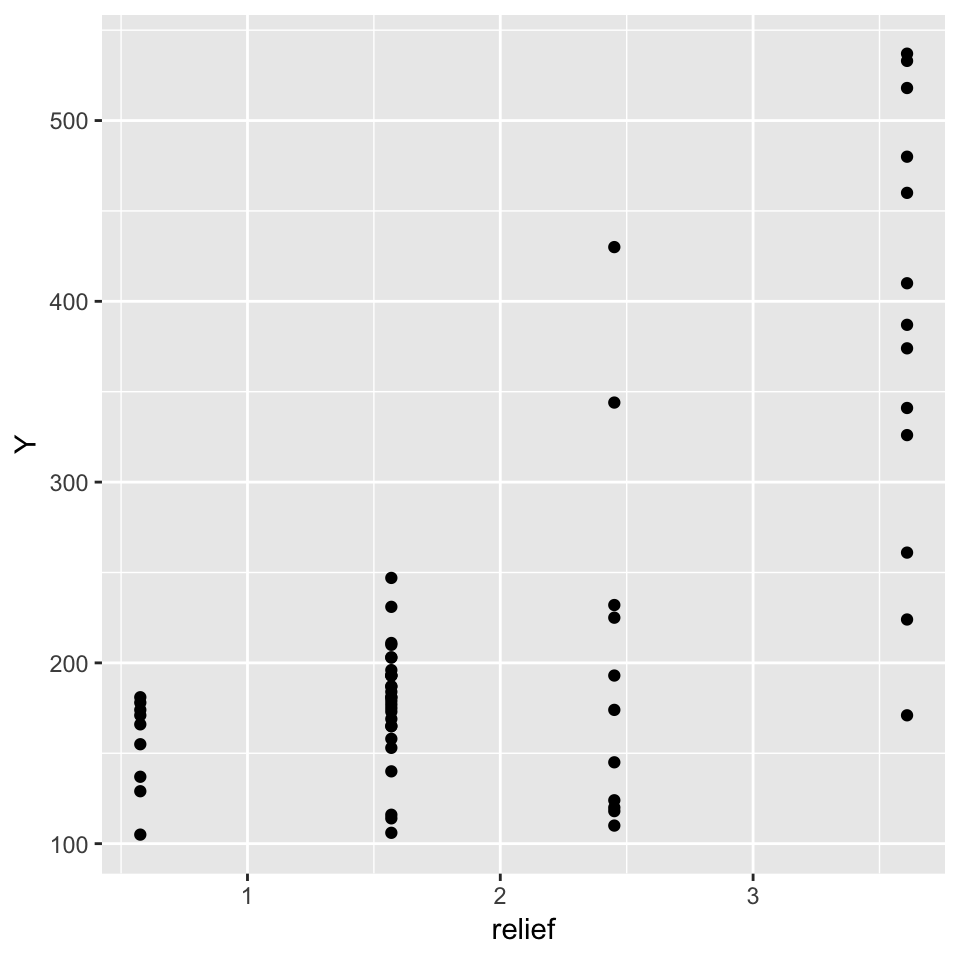

## Poisson regression

The data is bounded to positive values, a log-link is thus recommended:

\(counts_{expected} = log^{-1}(\beta_0 + \beta_1 * relief)\)

As the data can only take natural numbers (0, 1, 2, …), we need a discrete data distrubution. For count models, the Poisson distribution is a good choice, yielding the final model of:

\(counts \sim Poisson(log^{-1}(\beta_0 + \beta_1 * relief))\)

## Poisson regression

Fitting a Poisson model in R:

```r
fit <- glm(Y ~ relief, data = dat, family = poisson(link = "log"))
```

And plotting the regression line:

```r
efct <- effect("relief",
               mod = fit,
               xlevels = list(relief = seq(0, 4, length.out = 100)))
efct <- as.data.frame(efct)

p <- ggplot() +
  geom_point(data = dat, aes(x = relief, y = Y)) +
  geom_ribbon(data = efct, aes(x = relief, ymin = lower, ymax = upper), alpha = 0.3) +
  geom_line(data = efct, aes(x = relief, y = fit))
```

## Poisson regression

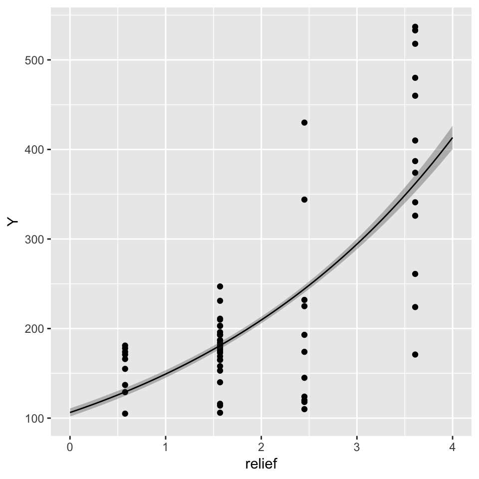

## Poisson regression

The coefficients of the Poisson model can be interpreted easily, as the coefficients are multiplicative when backtransformed to the response scale. That is, with a one unit increase in x, the count is multiplied by the exponent of the coefficient.

For our example, we expect:

```r
exp(coef(fit)[2])
```

```
##   relief
## 1.404328
```

a 1.4 times (or 40%) increase in mean bird counts with a one unit increase in relief.